# Meta-analysis tutorial

```r
library(curatedMetagenomicData)
library(mia)
library(limma)
library(DT)
library(tidyverse)
library(kableExtra)
library(meta)
library(GUniFrac)
```

# 1 Introduction

These scripts are based on a tutorial by `curatedMetagenomicDataAnalysis` at this [link](https://waldronlab.io/curatedMetagenomicDataAnalyses/articles/Sex_metaanalysis_vignette.html).

```r
#Filter on Age, body_site, study_condition and remove samples missing BMI
metadata <- curatedMetagenomicData::sampleMetadata %>%
  filter(age >= 16 &
           body_site == "stool" &
           study_condition == "control" &
           is.na(BMI) != TRUE &
           is.na(gender) != TRUE &
           days_from_first_collection %in% c(0,NA))

metadata <- metadata %>%
  group_by(study_name, subject_id) %>%
  filter(row_number() == 1) %>%
  ungroup()


#Apply function to grouped selected dataset
datasets_tokeep <- metadata %>%
    select(study_name, gender) %>%
    group_by(study_name) %>%
    summarise(n_males = sum(gender=="male"),
              n_females= sum(gender=="female"),
              N=n()) %>%
    mutate(keep = (pmin(n_males,n_females) >= 40) & (n_females/N >= 0.25) & (n_males/N >= 0.25)) %>%
    filter(keep == TRUE)

datasets_tokeep <- datasets_tokeep$study_name

metadata <- metadata %>%
    filter(study_name %in% datasets_tokeep)
```

```r
data_ready <- suppressMessages(
  returnSamples(metadata, "relative_abundance", rownames = "short")
)

species_data_ready <- splitByRanks(data_ready, rank = "species")[[1]]
```

We need to generate functions to compute the meta-analysis a follows

$$Weighted~\beta_i (Cohen's~D) = t\cdot \frac{(n_1 + n_2)}{\sqrt{n_1 \cdot n_2}\cdot \sqrt{n_1 + n_2 - 2}}$$

- $n_1~\&~n_2$ are respectively **Number of Controls** and **Number of Cases**
- $t$ is the t-statistic of the binary or continuous variable tested (e.g. sex). NB: multi-level variables need different handling

```r
d_fromlm <- function(n1,n2,t) {
  d <- (t*(n1+n2)/(sqrt(n1*n2)*sqrt(n1+n2-2)))
  return(d)
}
```

Then we need the variance of the $\beta$ effect sizes, which gets computed as follows:

$$Var(\beta) = \frac{n_1+n_2 - 1}{n1 + n_2 - 3}\cdot \frac{4}{n_1+n_2}\cdot(1 + \frac{\beta^2}{8})$$

$$S.E.(\beta) = \sqrt{Var(\beta)}$$

```r
#Compute Std. error of d
SE_d <- function(n1,n2,d) {
  se_d <- sqrt(((n1+n2-1)/(n1+n2-3))*((4/(n1+n2))*(1+((d**2)/8))))
  return(se_d)
}
```

Another implementation of Cohen’s standardized D is a constant value, regardless of the sample size imbalance.

$$D_2 = t \cdot \sqrt{\frac{2}{df}}$$

Looking at the two ways to scale effect sizes, their relationship with sample size and case/control imbalance is the following:

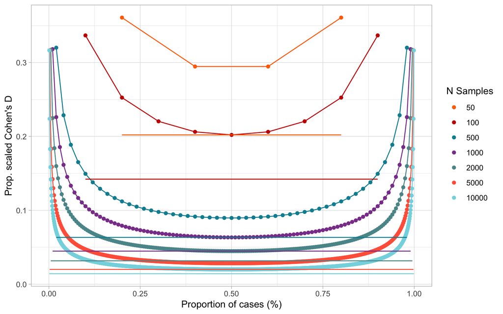

```r
N <- c(50, 100, 500, 1000, 2000, 5000, 10000)

names(N) <- paste("N =", N)
n_cases <- lapply(N, function(ntot) data.frame(
  N = ntot,
  Ncases = seq(10, ntot - 10, 10)) |>
    mutate(
  D1.const = sqrt(2/(N - 1)),
  D2.const = N/(sqrt((N - Ncases)*Ncases)*sqrt(N - 2))
  ))


bind_rows(n_cases) |>

  ggplot(
    aes(x = Ncases/N, y = D2.const, color = as.factor(N))
  ) +
  geom_line(show.legend = FALSE) +
  geom_point() +
  theme_light() +
  scale_color_manual(values = ggsci::pal_futurama()(7)) +
  geom_line(aes(x = Ncases/N, y = D1.const), show.legend = FALSE) +
  labs(
    x = "Proportion of cases (%)",
    y = "Prop. scaled Cohen's D",
    color = "N Samples"
  )
```

Notice that the second formulation, as horizontal lines, is significantly lower than the first formulation.

The formula for the standard error follows the same simulated values has a constant component and a variable component.

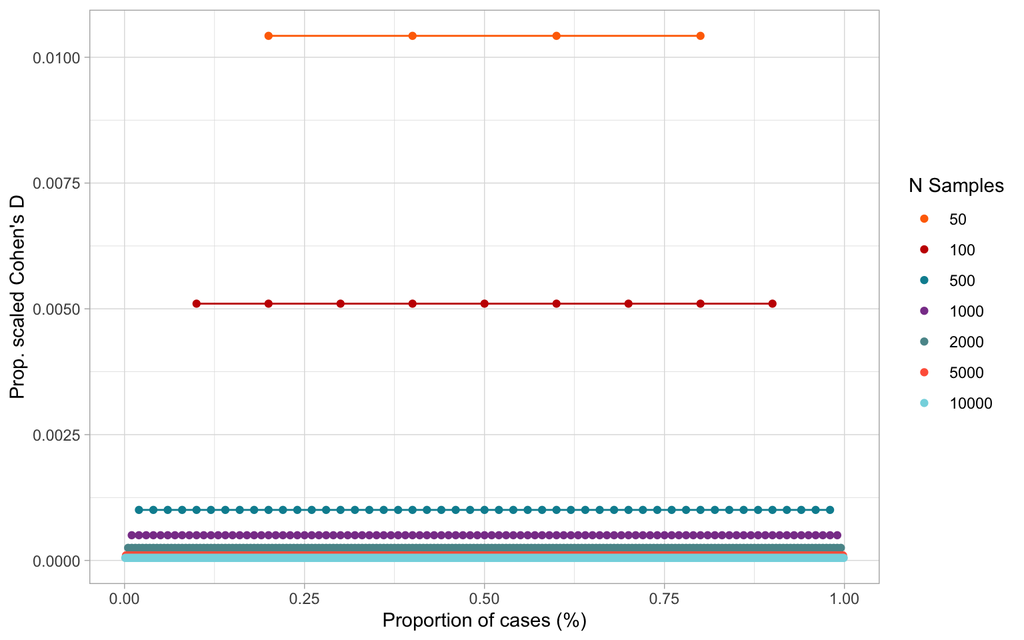

```r
N <- c(50, 100, 500, 1000, 2000, 5000, 10000)
names(N) <- paste("N =", N)
n_cases <- lapply(N, function(ntot) data.frame(
  N = ntot,
  Ncases = seq(10, ntot - 10, 10)) |>
    mutate(
  D2_SE.const = (N - 1)/(N - 3)/2/N
  ))


bind_rows(n_cases) |>

  ggplot(
    aes(x = Ncases/N, y = D2_SE.const, color = as.factor(N))
  ) +
  geom_line(show.legend = FALSE) +
  geom_point() +
  theme_light() +
  scale_color_manual(values = ggsci::pal_futurama()(7)) +
  labs(
    x = "Proportion of cases (%)",
    y = "Prop. scaled Cohen's D",
    color = "N Samples"
  )
```

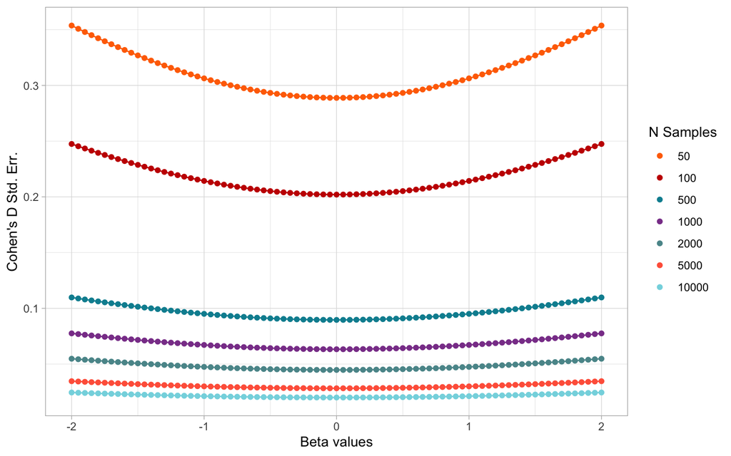

```r
betas = seq(-2, 2, 0.05)
N <- c(50, 100, 500, 1000, 2000, 5000, 10000)
expand.grid(betas, N) |>
  rename(
    Beta = Var1,
    N = Var2
  ) |>
mutate(
  cohen_SE = sqrt((N - 1)/(N - 3)* 4/(N) * (1 + Beta^2/8))
  ) |>

  ggplot(
    aes(
      x = Beta,
      y = cohen_SE,
      color = as.factor(N)
    )
  ) +
  geom_line(show.legend = FALSE) +
  geom_point() +
  scale_color_manual(values = ggsci::pal_futurama()(7)) +
  theme_light() +
  labs(
    x = "Beta values",
    y = "Cohen's D Std. Err.",
    color = "N Samples"
  )
```

Again, we see that the lowest values of Std. Errors are reached with larger sample sizes, which is ok, but with lowest Beta values. This is does not sound correct, because the uncertainty of Cohen’s D should increase with decreasing Beta values.

# 2 Meta-analysis on sex using `cMD Analysis` tutorial

```r
method1_t0 <- Sys.time()
```

```r
asin_trans <- function(rel_ab){
  return(asin(sqrt(rel_ab/100)))
}
```

```r
#Function that takes in input a tse object and for each dataset computes a linear model for each linear species

computeStandardizedMeanDifference <- function(tse_object){

  tse_datasets <- unique(colData(tse_object)$study_name)

  #Build linear models for all species of each dataset present in tse_object
  singleDatasetAnalyze <- function(dataset) {
    single_dataset_tse <- tse_object[,tse_object$study_name == dataset]

    #Select vectors of relative abundances and metadata
    exprs_df <- asin_trans(
     assay(single_dataset_tse))

    exprs_df <- exprs_df[rowSums(is.na(exprs_df)) != ncol(exprs_df), ]

    species <- rownames(exprs_df)

    age <- colData(single_dataset_tse)$age
    bmi <- colData(single_dataset_tse)$BMI
    gender <- as.factor(colData(single_dataset_tse)$gender)

    compute_lm <- function(exprs_row){
      lm_res <-  broom::tidy(lm(exprs_row ~ bmi + age + gender))
      lm_res <- column_to_rownames(lm_res, var = "term")
      res <- lm_res["gendermale",c("statistic","p.value"),drop=TRUE]
      return(res)
    }

    lmResults <- t(
      sapply(species,
            FUN = function(x) {
              species_relabs <- exprs_df[x,]
              res <- compute_lm(species_relabs)
              return(res)
                        }))

    n_gender <- c(table(gender)["male"][[1]],
                  table(gender)["female"][[1]])

    #Compute effect size and respective standard error for each species
    #in single dataset

    d_List <- as.vector(sapply(lmResults[,"statistic"], function(x) d_fromlm(n_gender[1],
                                                                   n_gender[2],
                                                                   x)))

    SE_d_List <- as.vector(sapply(d_List, function(x) SE_d(n_gender[1],
                                                           n_gender[2],
                                                           x )))

    #Wald test for relative abundance of species between males and females
    #(default of lm() function)
    wald_list <- as.double(lmResults[,"p.value", drop=TRUE])

    #FDR-correction with Benjamini-Hochberg method for Wald p-values
    q_values <- p.adjust(wald_list,method = "BH")


    final_df <- as.matrix(cbind(d_List,
                                SE_d_List,
                                wald_list,
                                q_values))

    #Finalize results for the single dataset
    colnames(final_df) <- c(paste0(dataset,"_CohenD"),
                            paste0(dataset,"_SE_d"),
                            paste0(dataset,"_pvalue"),
                            paste0(dataset,"_Qvalue"))

    rownames(final_df) <- species

    return(final_df)

  }

    linear_models <- lapply(tse_datasets, singleDatasetAnalyze)
    names(linear_models) <- tse_datasets

    return(linear_models)

}
```

```r
runMetaanalysis <- function(d_vector, SE_d_vector) {
  a <- meta::metagen(TE=d_vector,
                     seTE=SE_d_vector,
                     studlab=rownames(d_vector),
                     method.tau="PM",
                     sm="SMD")

  final_vector <-c(a$TE.random,
                   a$seTE.random,
                   paste(a$lower.random,a$upper.random,sep=";"),
                   a$zval.random,
                   a$pval.random,
                   a$tau2,
                   a$I2)

  names(final_vector) <- c("RE","SE_RE","CI_RE","Zscore","p-value","tau2","I^2")

  return(final_vector)
}
```

```r
#Computing Standardized Mean Differences (d), and the respective standard error
#(SE_D) of species relative abundances between males and female for all datasets
#Retrieve queried samples

#Separating Asnicar USA from Asnicar GBR
# colData(species_data_ready)[which(colData(species_data_ready)$study_name == "AsnicarF_2021" & colData(species_data_ready)$country == "USA"),]$study_name <- "USA_asnicarF_2021"

SDM <- computeStandardizedMeanDifference(species_data_ready)

#Merging outputs of all datasets so to have a single dataframe with all the
#species found across the cohorts
final_df <- Reduce(function(x, y) merge(x, y, all=TRUE),
                   lapply(SDM, function(x) data.frame(x, rn = row.names(x))))

final_df <- final_df  %>% column_to_rownames(var="rn")

#Subsetting from SDM dataframe only the columns we actually need to perform
#the meta-analysis into two separated dataframes (one for the standardized mean
#differences (d), and one for the respective standard error (SE_D)

d_matrix <- final_df %>%
  select(contains("CohenD"))
d_matrix <- t(d_matrix)
se_matrix <- final_df %>%
  select(contains("SE_d"))
se_matrix <- t(se_matrix)

#Run meta-analyses
meta_analysis_regression <- t(mapply(function(x,y) {runMetaanalysis(x,y)},
                                                   as.data.frame(d_matrix),
                                                   as.data.frame(se_matrix)))

final_df <- cbind(final_df, meta_analysis_regression)

#Correct p-values of random effect with FDR Benjamini-Hochberg
final_df$FDR_Qvalue <- p.adjust(final_df$`p-value`,method = "BH")
```

```r
filter_sort <- function(df_to_sort, na_filter){
  cols_cohenD <- grep("CohenD|Correlation",colnames(df_to_sort))
  cols_cohenD <- cols_cohenD[which(cols_cohenD >= 9)]
  df_to_sort$na_n <- apply(df_to_sort[,cols_cohenD], MARGIN = 1, FUN = function(x){
     na_n <- sum(!is.na(x))
   })

  df_to_sort <- df_to_sort[which(df_to_sort$na_n >= na_filter),]
  df_to_sort$RE_correlation_ABS <- abs(as.double(df_to_sort[,1]))
  df_to_sort$lower_than_fdr <- ifelse(df_to_sort$FDR_Qvalue < 0.2, 1, 0)

  #Split the dataset
  df_to_sort_lower_fdr <- df_to_sort[which(df_to_sort$lower_than_fdr == 1),]
  df_to_sort_upper_fdr <- df_to_sort[which(df_to_sort$lower_than_fdr == 0),]

  #Sort according to ABS.re
  df_to_sort_lower_fdr <- df_to_sort_lower_fdr %>%
    arrange(-RE_correlation_ABS)

  df_to_sort_upper_fdr <- df_to_sort_upper_fdr %>%
    arrange( -RE_correlation_ABS)

  df_to_sort <- rbind(df_to_sort_lower_fdr, df_to_sort_upper_fdr)
  df_to_sort <- df_to_sort %>%
    select(-c(na_n, lower_than_fdr,RE_correlation_ABS))

  return(df_to_sort)
}

final_df <- final_df %>% dplyr::select(RE:FDR_Qvalue,everything())
final_df <- filter_sort(final_df, 4)
```

```r
method1_t1 <- Sys.time()
```

```r
datatable(final_df)
```

|  | RE | SE_RE | CI_RE | Zscore | p-value | tau2 | I^2 | FDR_Qvalue | AsnicarF_2021_CohenD | AsnicarF_2021_SE_d | AsnicarF_2021_pvalue | AsnicarF_2021_Qvalue | DeFilippisF_2019_CohenD | DeFilippisF_2019_SE_d | DeFilippisF_2019_pvalue | DeFilippisF_2019_Qvalue | DhakanDB_2019_CohenD | DhakanDB_2019_SE_d | DhakanDB_2019_pvalue | DhakanDB_2019_Qvalue | HMP_2012_CohenD | HMP_2012_SE_d | HMP_2012_pvalue | HMP_2012_Qvalue | KeohaneDM_2020_CohenD | KeohaneDM_2020_SE_d | KeohaneDM_2020_pvalue | KeohaneDM_2020_Qvalue | LifeLinesDeep_2016_CohenD | … |
| --- | --- | --- | --- | --- | --- | --- | --- | --- | --- | --- | --- | --- | --- | --- | --- | --- | --- | --- | --- | --- | --- | --- | --- | --- | --- | --- | --- | --- | --- | --- |
| Ruthenibacterium lactatiformans | -0.29202537872381 | 0.0616170711231999 | -0.412792618958125;-0.171258138489496 | -4.7393583206823 | 2.14396081014563e-06 | 0.014920648320029 | 0.402605026508168 | 0.0001781436527702823 | -0.2591351347056439 | 0.06069297109735971 | 0.0001271510472688163 | 0.02008986546847297 | -0.9341761784164622 | 0.2161216923694475 | 1.639773732419295e-05 | 0.004915154199339261 | -0.2688082200003074 | 0.2154168259692226 | 0.2136686255177072 | 0.543477295899481 | -0.4002520946542606 | 0.2094805282906839 | 0.05739091356486234 | 0.5943160340672768 | -0.2562707057063424 | 0.1880988136612494 | 0.1771581466845883 | 0.71140917022745 | -0.1404522785271634 | … |
| Akkermansia muciniphila | -0.270926041302948 | 0.0357265288154883 | -0.340948751073937;-0.200903331531958 | -7.58332953929448 | 3.367979503512e-14 | 0 | 0 | 3.078333266209968e-11 | -0.1697440123637167 | 0.06054858198767431 | 0.01190759341018151 | 0.2033945685198572 | -0.4833156829487074 | 0.2081927252150461 | 0.02076879316032432 | 0.4224717028953899 | -0.3869859147674632 | 0.2164484441342275 | 0.07481223076960436 | 0.543477295899481 | -0.5113735097728079 | 0.2107767683555716 | 0.0158215815356893 | 0.5943160340672768 | -0.2283277135960705 | 0.1879408516496086 | 0.2288164416007455 | 0.71140917022745 | -0.3028602341036296 | … |
| Gordonibacter pamelaeae | -0.2550192265054 | 0.0357059910460505 | -0.325001682987969;-0.185036770022832 | -7.14219712250804 | 9.18507461857202e-13 | 0 | 0 | 4.197579100687413e-10 | -0.1967151126290345 | 0.06058583944763124 | 0.003579477311011089 | 0.1234048095357279 | -0.42413198304493 | 0.2075126142974541 | 0.04178229022545824 | 0.5239127056930925 | -0.4420569539120063 | 0.2170538868253815 | 0.04241376855011172 | 0.543477295899481 | -0.3662655189876663 | 0.2091458794287136 | 0.08155208355486325 | 0.5943160340672768 | -0.3931129538767392 | 0.1891321593337274 | 0.03949882493078593 | 0.6750708260897959 | -0.2655411116611659 | … |
| Bilophila wadsworthia | -0.249461965576975 | 0.0370320669739807 | -0.322043483119053;-0.176880448034898 | -6.73637703648169 | 1.62384590303316e-11 | 0.000376721099492647 | 0.0359004324367592 | 4.94731718457436e-09 | -0.3375325902502408 | 0.06086868030960159 | 6.370632630076064e-07 | 0.0004026239822208072 | -0.5966528417533138 | 0.209734512262699 | 0.004603940799783676 | 0.2439926864378986 | -0.1049214102019835 | 0.2145980175415058 | 0.626070925386929 | 0.7758206404320147 | 0.03027530712387145 | 0.2074259482785812 | 0.8845706815245336 | 0.9490478543421944 | -0.2164781121483779 | 0.1878793303468257 | 0.2537316954292078 | 0.71140917022745 | -0.188586860384416 | … |
| Catenibacterium mitsuokai | 0.238151676085377 | 0.0356873068197375 | 0.16820584001346;0.308097512157293 | 6.67328799251566 | 2.50134839601002e-11 | 0 | 0 | 5.715581084882895e-09 | 0.2817919881133565 | 0.06073905632273686 | 3.121643177905735e-05 | 0.008540368133641684 | 0.5509410811400652 | 0.2090751240608369 | 0.008674987394066865 | 0.3036245587923402 | 0.2847516730484769 | 0.2155345548311993 | 0.1879837509618917 | 0.543477295899481 | 0.4272907623938387 | 0.2097675344019428 | 0.04277322071730058 | 0.5943160340672768 | 0.1610780912608356 | 0.1876349892899901 | 0.3951287854161256 | 0.7163990521357166 | 0.1738991419952764 | … |
| Alistipes finegoldii | -0.222316689642197 | 0.0510561710311539 | -0.322384946051776;-0.122248433232618 | -4.35435492227848 | 1.33459330093301e-05 | 0.0066953316041924 | 0.160626590833897 | 0.0008063160498107608 | -0.2307285304680033 | 0.06064060259332874 | 0.000639641032304029 | 0.0577504474880209 | -0.4921960670707363 | 0.2083022206896337 | 0.01860213444040692 | 0.4224717028953899 | -0.2308133883542111 | 0.2151633855434893 | 0.2850473624120028 | 0.543477295899481 | -0.2958125409906467 | 0.2085453426246949 | 0.1583060880110776 | 0.5943160340672768 | -0.3132210657261034 | 0.1884766148849005 | 0.09972798277363487 | 0.71140917022745 | -0.2295229462258257 | … |
| Bacteroides thetaiotaomicron | -0.218211871820536 | 0.0674000438463129 | -0.35031353031573;-0.0861102133253427 | -3.2375627576461 | 0.00120555420801868 | 0.0209912143290204 | 0.427020308904751 | 0.02899675121392299 | -0.1055897408944175 | 0.06048194018529392 | 0.1174023577408321 | 0.5351145664732144 | -0.1488625723972003 | 0.2055022050973151 | 0.4705763911890974 | 0.7263986836248075 | -0.6903500141098935 | 0.220745837153831 | 0.001829201705949907 | 0.2579174405389369 | 0.1306955905890594 | 0.2076353802411613 | 0.5312649964898652 | 0.7053000815468902 | -0.1117502015176102 | 0.187477608506038 | 0.5548956536585085 | 0.7592026246473038 | -0.1683371901585261 | … |
| Prevotella sp. AM42-24 | 0.217981625871728 | 0.0547976815288044 | 0.110580143638975;0.32538310810448 | 3.97793519342868 | 6.95163114373828e-05 | 0.00925924250363978 | 0.41557017759618 | 0.002541516346150715 | 0.2776987372587004 | 0.06073044736442591 | 4.053972215336242e-05 | 0.008540368133641684 | 0.5131451593348176 | 0.2085681825051271 | 0.01426746902259575 | 0.3975453750235616 | 0.2621069946385607 | 0.2153693491236645 | 0.2252019347017754 | 0.543477295899481 | -0.03226581290140508 | 0.2074275619709796 | 0.877041033086217 | 0.9483113942198697 | 0.585420803860628 | 0.1913019845364369 | 0.002429415043010356 | 0.1826920112343788 | 0.07562680428110358 | … |
| Firmicutes bacterium CAG:145 | -0.211671183186109 | 0.0640571169591865 | -0.337220825379585;-0.0861215409926337 | -3.30441320549868 | 0.000951754409708942 | 0.0132854229462819 | 0.292390881330823 | 0.02485438658497065 | -0.1548686109742256 | 0.06053037148021662 | 0.02173096333504071 | 0.286124350578036 | -0.2567945556471424 | 0.2060622373924754 | 0.2145093075976602 | 0.6237633064201359 |  |  |  |  | -0.6239256461462149 | 0.2124005517625553 | 0.003479698872753709 | 0.5349901796833377 | -0.3369145472073774 | 0.1886557869920392 | 0.07688936835043783 | 0.71140917022745 | -0.2141562746286458 | … |
| Prevotella copri | 0.2090272920948 | 0.0497669628087181 | 0.111485837369769;0.306568746819832 | 4.20012153239505 | 2.66771747033388e-05 | 0.00590150027983675 | 0.264925778211697 | 0.001354607648825092 | 0.1847752098728287 | 0.06056867217386953 | 0.006203294471468297 | 0.1392231413374706 | 0.4810518455351491 | 0.2081651218068914 | 0.02135571245405268 | 0.4224717028953899 | 0.3593564121558289 | 0.2161744344735388 | 0.09761473718282934 | 0.543477295899481 | 0.4191966081515317 | 0.2096796926363013 | 0.0467703667435154 | 0.5943160340672768 | 0.3468054449846114 | 0.1887343928313705 | 0.06872734382343565 | 0.71140917022745 | 0.08279677628978054 | … |

[output cut: 522 more lines]